# Question

A polynomial is sketched below.

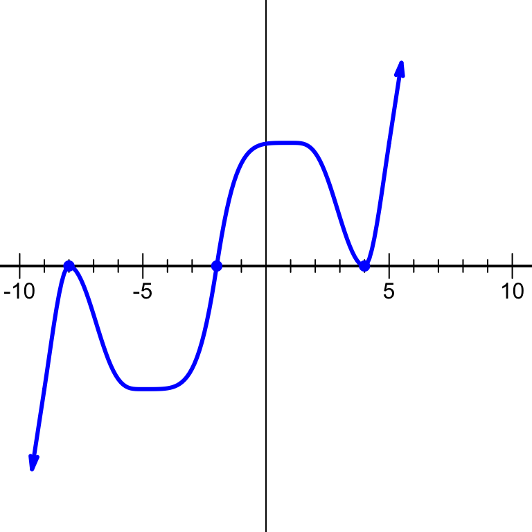

Which polynomial (in factored form) best matches the sketch?

## Answerlist

- $y=-(x+2)(x+8)^2(x-4)^2$
- $y=(x+2)(x+8)(x-4)$
- $y=-(x+2)(x+8)(x-4)$
- $y=(x+2)(x+8)^2(x-4)^2$

# Solution

If a polynomial has a factor of $x-r$, then there will be an $x$-intercept at point $(r,0)$.

In this case, the roots (the $x$-intercepts) are at:

$$-8,\,-2,\,4$$

Thus, the factors are $x+8$ and $x+2$ and $x-4$. Notice, the $x$-intercepts where the curve “bounces” off the $x$ axis correspond to an even multiplicity, in this case a multiplicity of 2. So, we know the curve could be represented by the function below:

$$y=a(x+8)^2(x+2)(x-4)^2$$

where $a$ is some constant.

Lastly, we need to determine whether $a$ should be positive or negative. In this problem, either $a=1$ or $a=-1$. To determine this, look at the right side of the graph. Specifically, we are considering the [end behavior of polynomials](https://www.khanacademy.org/math/algebra2/x2ec2f6f830c9fb89:poly-graphs/x2ec2f6f830c9fb89:poly-end-behavior/a/end-behavior-of-polynomials). Notice that once $x$ is larger than $4$, all the factors will be positive, so only $a$ will dictate whether the function on the right side is positive or negative.

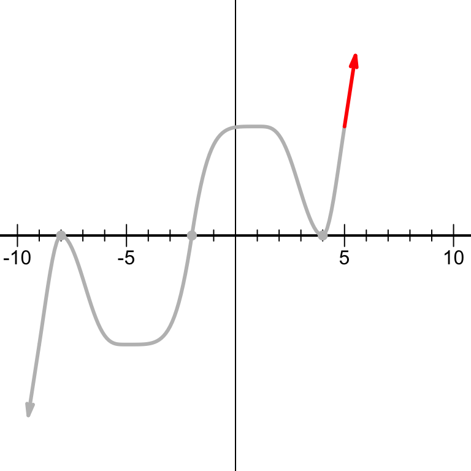

Notice, on the right side, the function is heading up. I guess more importantly, as $x\to \infty$ we see the function is positive. This implies that $a$ is positive. So, in this case, $a=1$.

$$y=(x+8)^2(x+2)(x-4)^2$$

And then, since multiplication is commutative, the factors can be written in any order. In this case, the correct answer is:

$$y=(x+2)(x+8)^2(x-4)^2$$

# Meta-information

extype: schoice exsolution: 0001 exname: poly_sketch